# BCC125_sea_lamprey_scRNA

Stephanie Hickey

2024-12-06

#### Lab: Weiming Li

#### Project: BCC125_sea_lamprey_scRNA

#### Sample: TF_C00004337

## Detect empty droplets with `DropletUtils`

Empty droplets often contain RNA from the ambient solution, resulting in non-zero counts after debarcoding. The `emptyDrops` function is designed to distinguish between empty droplets and cells. It does so by testing each barcode’s expression profile for significant deviation from the ambient profile. Using this method, 17083 barcodes represent cells.

Below is a barcode rank plot, or knee plot, which shows the (log-)total UMI count for each barcode on the y-axis and the (log-)rank on the x-axis. The plot resembles a curve with a sharp “knee” or “elbow.” Cells with high RNA content (likely real biological cells), are on the left side of the plot. Low-RNA-content cells (likely empty droplets or low-quality cells) are on the right side. The “knee” or transition point marks the threshold between high-quality cells and low-quality or empty droplets.

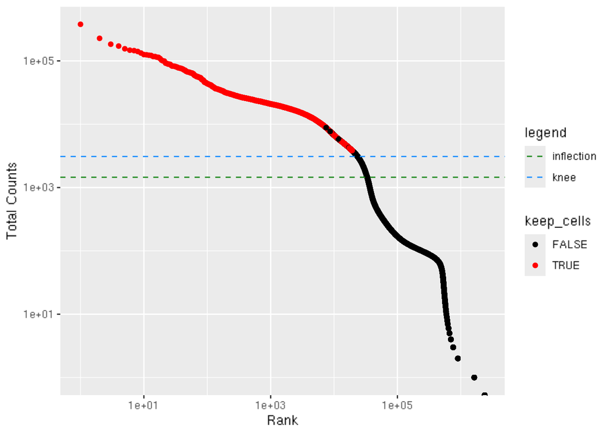

## Identifying low quality cells

Common metrics include for identifying low quality cells include:

- Total counts
- Number of expressed features (genes)
- Proportion of reads mapped to genes in the mitochondrial genome

For each cell, we calculate these QC metrics using the `perCellQCMetrics()` function from the `scater` package.

### Summarize the stats

The total counts in each cell:

```
##    Min. 1st Qu.  Median    Mean 3rd Qu.    Max.
##    3709    4808    7122    9878   12957  378407
```

The number of genes with at least one count in each cell:

```
##    Min. 1st Qu.  Median    Mean 3rd Qu.    Max.
##     485    1128    1416    1730    2256    9731
```

These are the genes on the mitochondrial chromosome, NC_001626.1.

```
##  [1] "CYTB" "ND1"  "ND2"  "COX1" "COX2" "ATP8" "ATP6" "COX3" "ND3"  "ND4L"
## [11] "ND4"  "ND5"  "ND6"
```

The percent of counts that come from mitochrondria genes:

```
##    Min. 1st Qu.  Median    Mean 3rd Qu.    Max.
##  0.0000  0.4806  0.8147  1.5806  2.2167 23.2704
```

Normally, I would filter out cells with high percent mitochondria, but female germ cells likely have biologically high percent mitochondria. So I will cluster first and attempt to identify female germ cells before performing any QC filtering.

## Cluster the cells and check for enrichment of known cell-type markers

The plot below is a UMAP dimentionality reduction plot where each cell is a dot colored by its cluster membership.

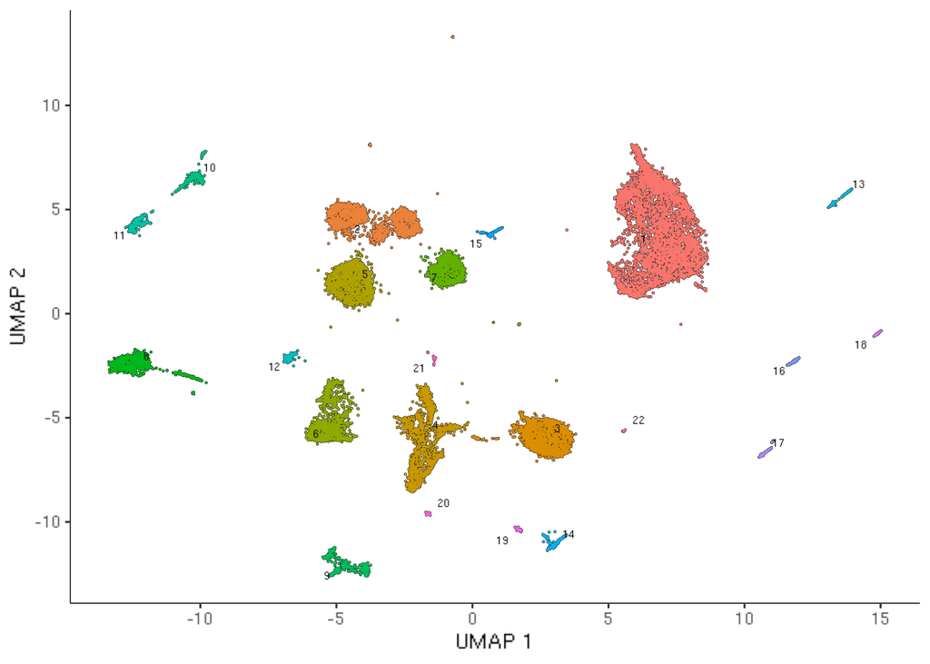

This table contains the top ~100 cluster enriched genes for each cluster after removing mitochondria genes. It is saved in TF_C00004337_cluster_marker_genes.csv. The markers can help us map a cluster to a cell type.

**Column descriptions**

- `gene_id` vector of gene names
- `cell_group` character vector of the cell group to which the cell belongs
- `marker_score` numeric vector of marker scores as the fraction expressing scaled by the specificity. The value ranges from 0 to 1.
- `mean_expression` numeric vector of mean normalized expression of the gene in the cell group
- `fraction_expressing` numeric vector of fraction of cells expressing the gene within the cell group
- `specificity` numeric vector of a measure of how specific the gene’s expression is to the cell group based on the Jensen-Shannon divergence. The value ranges from 0 to 1.
- `pseudo_R2` numeric vector of pseudo R-squared values, a measure of how well the gene expression model fits the categorical data relative to the null model. The value ranges from 0 to 1.
- `marker_test_p_value` numeric vector of likelihood ratio p-values
- `marker_test_q_value` numeric vector of likelihood ratio q-values

| gene_id | cell_group | marker_score | mean_expression | fraction_expressing | specificity | pseudo_R2 | marker_test_p_value | marker_test_q_value |
| --- | --- | --- | --- | --- | --- | --- | --- | --- |
| LOC116944456 | 1 | 0.4303066346600065 | 0.969959058716936 | 0.6992674717877648 | 0.6153677269727329 | 0.6272075462564008 | 0 | 0 |
| LOC116942142 | 1 | 0.3247946334743436 | 0.4806181913673275 | 0.5131657097604435 | 0.6329234929316779 | 0.4554702259093142 | 0 | 0 |
| LOC116955742 | 1 | 0.5247133717836223 | 2.578660095365568 | 0.943377549000198 | 0.5562071859137621 | 0.8222378501493485 | 0 | 0 |
| DPYD | 1 | 0.3292799378877722 | 0.703803140130246 | 0.5832508414175411 | 0.5645597305740453 | 0.4862703313884149 | 0 | 0 |
| LOC116938836 | 1 | 0.527558172844682 | 1.475860672278856 | 0.8497327261928331 | 0.6208518944637671 | 0.7488752898575866 | 0 | 0 |
| LOC116939967 | 1 | 0.5827592226240776 | 2.458280720456526 | 0.9142744011086914 | 0.6374007868068896 | 0.8222471716765498 | 0 | 0 |
| LOC116941099 | 1 | 0.4645705504654472 | 0.8328653077907723 | 0.6477925163333993 | 0.7171594897313489 | 0.5984424858120754 | 0 | 0 |
| FTCD | 1 | 0.5923679317529744 | 2.416074234104959 | 0.9229855474163532 | 0.6417954575899343 | 0.8362673346031614 | 0 | 0 |
| LOC116950738 | 1 | 0.5946559459048468 | 3.451471107890115 | 0.9318946743219164 | 0.6381149740313111 | 0.8318387204749554 | 0 | 0 |
| LOC116953019 | 1 | 0.3548111268563509 | 0.7370757610716647 | 0.571965947337161 | 0.6203361030638381 | 0.4947620531660977 | 0 | 0 |

[output cut: 2190 more lines]

We’ll check for the significance of the overlap between the top 100 cluster enriched genes and the supplied known cell-type markers. In the plot below, the rows represent cell types with know marker genes, and the columns represent the cell clusters. The number in each box is the number of genes shared between the top 100 cluster enriched genes for the specified clusters and the specified known cell-type markers. Each box is colored by the significance of the overlap ($-log10(FDR)$). Significant overlaps may signfiy that the cells in the cluster belong to the specified cell type. In this case, female germ cells may be represented by cluster 9.

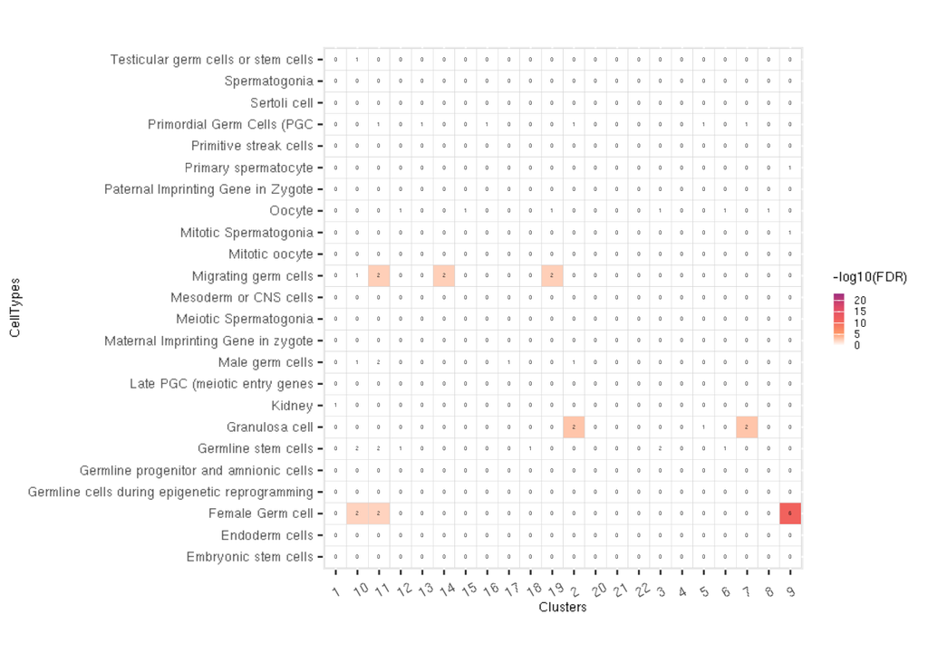

A table with the overlapping genes is shown below. Filtering for `Group1` = “Female Germ Cell” and `Group2` = “9” will show the genes shared between those groups.

|  | Group1 | Group2 | SharedGene |
| --- | --- | --- | --- |
| Maternal Imprinting Gene in zygote.1 | Maternal Imprinting Gene in zygote | 1 | none |
| Maternal Imprinting Gene in zygote.10 | Maternal Imprinting Gene in zygote | 10 | none |
| Maternal Imprinting Gene in zygote.11 | Maternal Imprinting Gene in zygote | 11 | none |
| Maternal Imprinting Gene in zygote.12 | Maternal Imprinting Gene in zygote | 12 | none |
| Maternal Imprinting Gene in zygote.13 | Maternal Imprinting Gene in zygote | 13 | none |
| Maternal Imprinting Gene in zygote.14 | Maternal Imprinting Gene in zygote | 14 | none |
| Maternal Imprinting Gene in zygote.15 | Maternal Imprinting Gene in zygote | 15 | none |
| Maternal Imprinting Gene in zygote.16 | Maternal Imprinting Gene in zygote | 16 | none |
| Maternal Imprinting Gene in zygote.17 | Maternal Imprinting Gene in zygote | 17 | none |
| Maternal Imprinting Gene in zygote.18 | Maternal Imprinting Gene in zygote | 18 | none |

[output cut: 534 more lines]

## Plot percent mitochodria reads per cell

Shown here is a UMAP dimentionality reduction plot where each cell is a dot colored by the percent mitochondria genes detected in the cell.

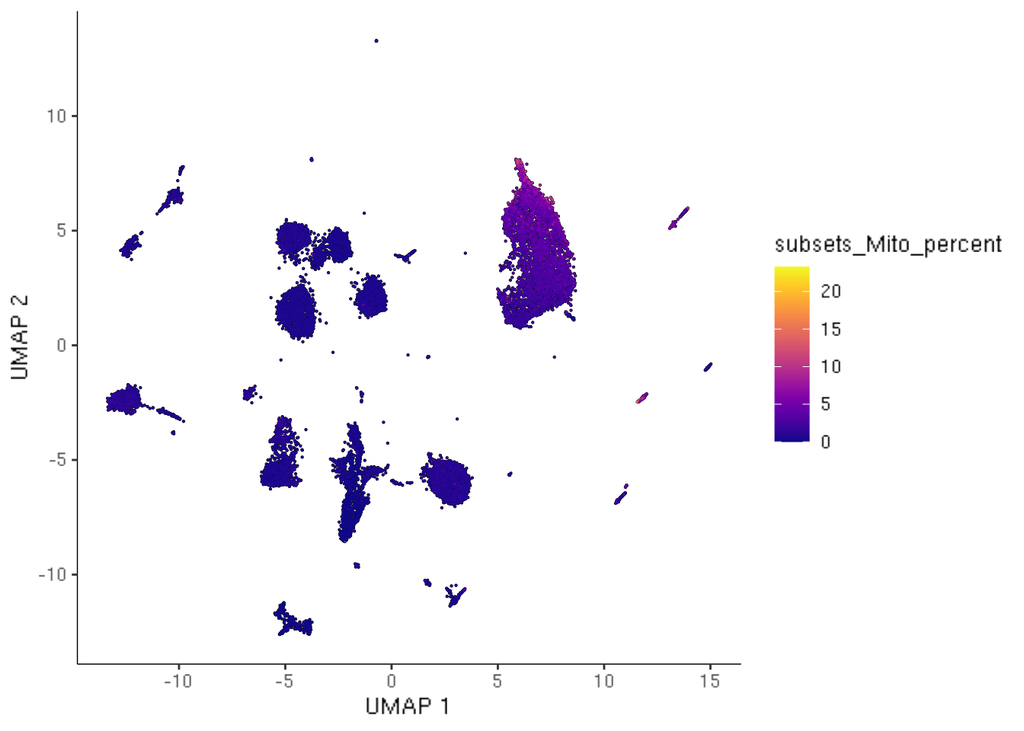

## Plot Mitochondria reads percent per cluster

Shown here is a violin plot showing the distribution of the mitochondria gene reads among cells in each cluster. The cells in Cluster 9, the presumed female germ cell cluster, do not have an unusually high percent of mitochondria reads. I’d like to filter cells for high mitochondria reads percentage to improve the dataset quality, if you agree that cluster 9 represents the female germ cells. I propose removing every cell above the red dotted line, percent mito > 2.8568618, which is 3 median absolute deviations (MAD) above the median percent mito. This is 3280 out of 17083 cells.

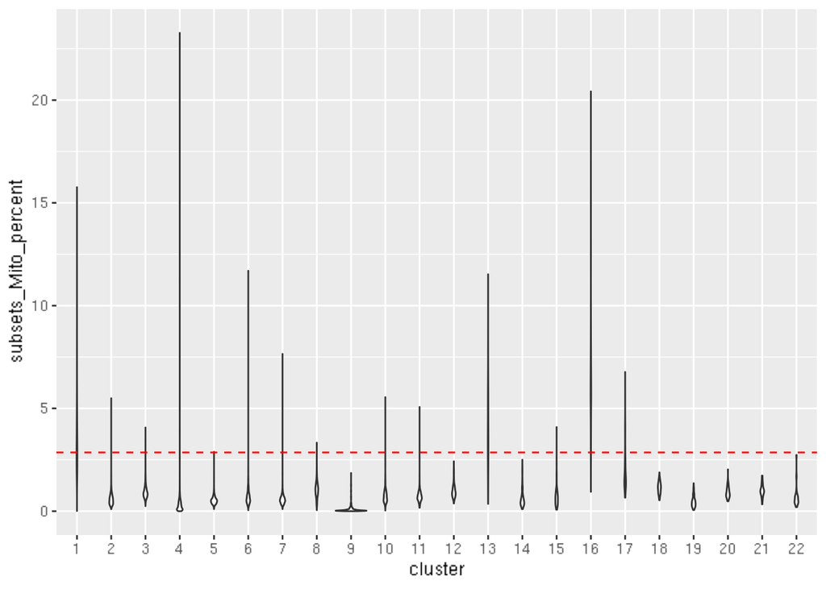

Shown here is a UMAP dimentionality reduction plot where each cell is a dot colored by whether or not the cell will be discarded.

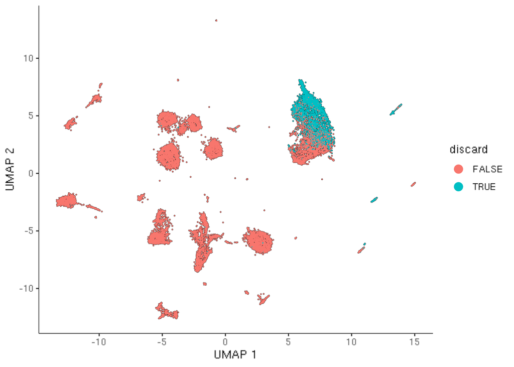

## Remove high mito cells and re-cluster

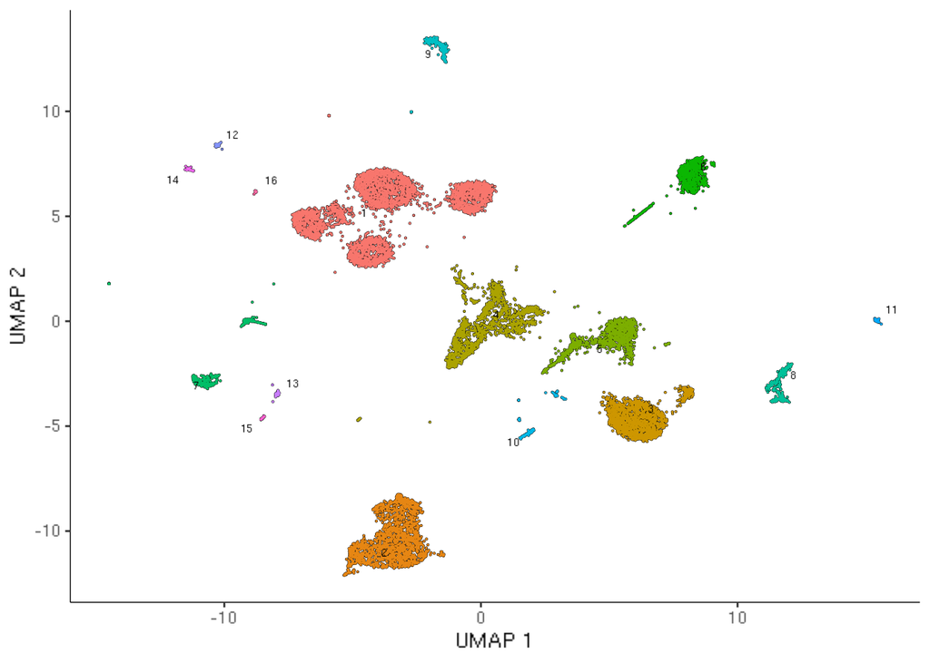

## Check for enrichment of known cell-type markers

This table contains the top ~100 cluster enriched genes for each cluster after removing mitochondria genes. It is saved in TF_C00004337_cluster_marker_genes_mito_filtered.csv. The markers can help us map a cluster to a cell type.

**Column descriptions**

- `gene_id` vector of gene names
- `cell_group` character vector of the cell group to which the cell belongs
- `marker_score` numeric vector of marker scores as the fraction expressing scaled by the specificity. The value ranges from 0 to 1.
- `mean_expression` numeric vector of mean normalized expression of the gene in the cell group
- `fraction_expressing` numeric vector of fraction of cells expressing the gene within the cell group
- `specificity` numeric vector of a measure of how specific the gene’s expression is to the cell group based on the Jensen-Shannon divergence. The value ranges from 0 to 1.
- `pseudo_R2` numeric vector of pseudo R-squared values, a measure of how well the gene expression model fits the categorical data relative to the null model. The value ranges from 0 to 1.
- `marker_test_p_value` numeric vector of likelihood ratio p-values
- `marker_test_q_value` numeric vector of likelihood ratio q-values

|  | gene_id | cell_group | marker_score | mean_expression | fraction_expressing | specificity | pseudo_R2 | marker_test_p_value | marker_test_q_value |
| --- | --- | --- | --- | --- | --- | --- | --- | --- | --- |
| 1 | LOC116943513 | 1 | 0.172359187118534 | 4.965360934636672 | 0.922060164083865 | 0.1869283522185189 | 0.2579460385956659 | 0 | 0 |
| 2 | LOC116957900 | 1 | 0.3109043646158371 | 4.167848338615138 | 0.8436645396536008 | 0.3685165726456762 | 0.4106311219415289 | 0 | 0 |
| 3 | LOC116938253 | 1 | 0.2513978872539477 | 1.774299516082969 | 0.5872835004557885 | 0.4280690451184799 | 0.3859919935426048 | 0 | 0 |
| 4 | ISYNA1 | 1 | 0.2872350470856076 | 12.63072166943057 | 0.9783500455788514 | 0.2935912850248419 | 0.5469935759297568 | 0 | 0 |
| 5 | LOC116940717 | 1 | 0.1442172219534225 | 17.70785311399649 | 0.9997721057429353 | 0.1442500957218186 | 0.3610106110829853 | 0 | 0 |
| 6 | RECK | 1 | 0.2715267666619426 | 2.724502392489903 | 0.763901549680948 | 0.3554473305825192 | 0.3784210800699482 | 0 | 0 |
| 7 | LOC116948243 | 1 | 0.1274563609619407 | 28.10731794342393 | 1 | 0.1274563609619407 | 0.2887869561811262 | 0 | 0 |
| 8 | WNT6 | 1 | 0.2759550944998918 | 1.528993895257997 | 0.5606198723792161 | 0.4922320953924899 | 0.3962072166946313 | 0 | 0 |
| 9 | LOC116949549 | 1 | 0.1291360222193617 | 27.51640210203484 | 1 | 0.1291360222193617 | 0.3558802595929118 | 0 | 0 |
| 10 | LOC116950144 | 1 | 0.1535312281308459 | 27.31421128468851 | 0.9993163172288059 | 0.1536362665993505 | 0.299272530293361 | 0 | 0 |

[output cut: 1590 more lines]

Again, we’ll check for the significance of the overlap between the top 100 cluster enriched genes and the supplied known cell-type markers. In the plot below, the rows represent cell types with know marker genes, and the columns represent the cell clusters. The number in each box is the number of genes shared between the top 100 cluster enriched genes for the specified clusters and the specified known cell-type markers. Each box is colored by the significance of the overlap ($-log10(FDR)$).

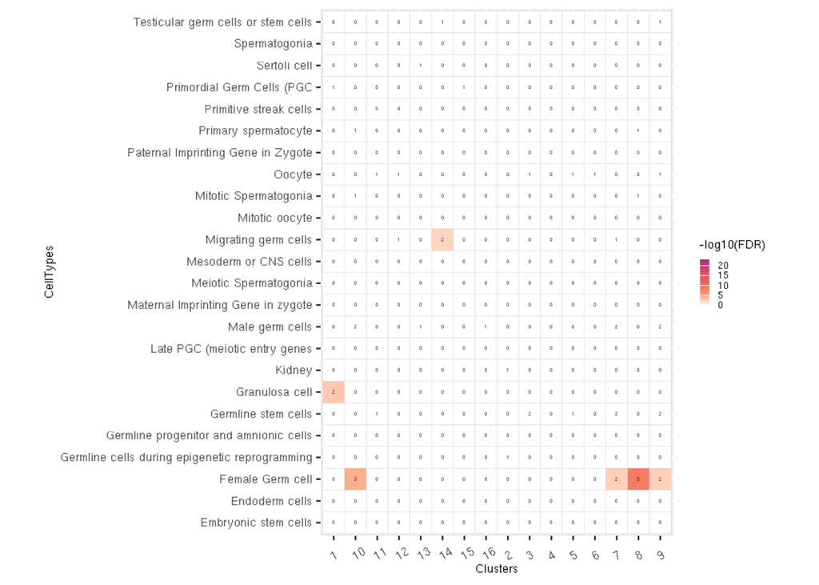

Now, cluster 8 is a likely female germ cell cluster. Although, there is weak evidence for any other cell-type classification with this method. Perhaps the results will be clearer when the four data sets are combined.

A table with the overlapping genes is shown below. Filtering for `Group1` = “Female Germ Cell” and `Group2` = “8” will show the genes shared between those groups.

| Group1 | Group2 | SharedGene |
| --- | --- | --- |
| Maternal Imprinting Gene in zygote | 1 | none |
| Maternal Imprinting Gene in zygote | 10 | none |
| Maternal Imprinting Gene in zygote | 11 | none |
| Maternal Imprinting Gene in zygote | 12 | none |
| Maternal Imprinting Gene in zygote | 13 | none |
| Maternal Imprinting Gene in zygote | 14 | none |
| Maternal Imprinting Gene in zygote | 15 | none |
| Maternal Imprinting Gene in zygote | 16 | none |
| Maternal Imprinting Gene in zygote | 2 | none |
| Maternal Imprinting Gene in zygote | 3 | none |

[output cut: 390 more lines]